# Solution

Yuri Kulchisky

30.03.2015

Подгружаем библиотеки

```r
library(dplyr,timeSeries)
library(timeSeries)
library(TTR)
library(lubridate)
library(zoo)
library(xts)
```

Получаем данные.

```r
setwd("~/OneDrive/Documents/Work")
load("wti.brent.RData")
```

Выгружаем данные по ценам на фьючерсы.

```r
brent <- select(brent.dataset,time,close)
wti <- select(wti.dataset,time,close)
```

Конвертируем их в xts-формат.

```r
brent1 <- xts(brent$close, order.by=as.POSIXct(strptime(brent$time,"%Y-%m-%dT%H:%M:%S.000")))
wti1 <- xts(wti$close, order.by=as.POSIXct(strptime(wti$time,"%Y-%m-%dT%H:%M:%S.000")))
```

Обрежем снизу и сверху общие для рядов NA и переведем данные в поминутные.

```r
lft <- max(time(first(wti1)),time(first(brent1)))
rht <- min(time(last(wti1)),time(last(brent1)))

brent2 <- brent1[time(brent1) %in% seq(lft,rht,by=60)]
wti2 <- wti1[time(wti1) %in% seq(lft,rht,by=60)]
```

Сведем данные в один ряд.

```r
tickDataRaw <- as.xts(merge(brent2,wti2))
```

```r
tickDataRaw_Work <- tickDataRaw[wday(time(tickDataRaw))<=5]
tickData <- na.approx(tickDataRaw_Work)
```

Покажем, как работает аппроксимация (были только данные, обозначенные красным).

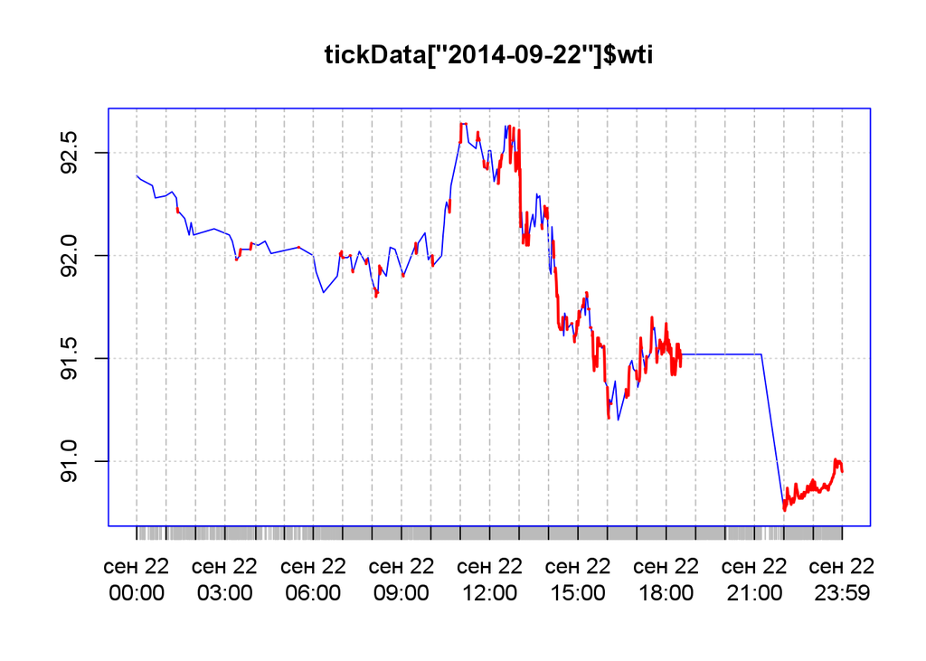

```r
par(col="blue",lwd=1)
plot(tickData["2014-09-22"]$wti)
par(col="red",lwd=2)
lines(tickDataRaw_Work["2014-09-22"]$wti)
```

Продолжим.

```r
tickData <- tickData[time(tickData)<="2015-03-23 21:14:00"] # Потом объясним
colnames(tickData) <- c("brent","wti")
head(tickData)
```

```
##                     brent   wti
## 2014-09-11 00:00:00 97.96 91.64
## 2014-09-11 00:01:00 97.92 91.63
## 2014-09-11 00:02:00 97.91 91.65
## 2014-09-11 00:03:00 97.93 91.63
## 2014-09-11 00:04:00 97.94 91.64
## 2014-09-11 00:05:00 97.95 91.63
```

Создадим ряд с отношением цен.

```r
r <- tickData$brent/tickData$wti
```

Нормализуем ряд с использованием скользящего среднего и стандартного отклонения с периодом, равным 10.

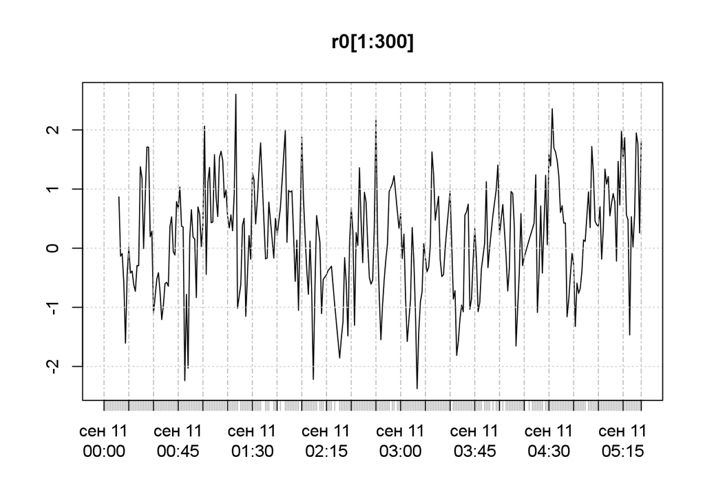

```r
mvPeriod <- 10
r0 <- (r-EMA(r,n=mvPeriod))/runSD(r,n=mvPeriod)
plot(r0[1:300],type="l")
```

Установим фиксированную границу, после которой будет создаваться сигнал на открытие/закрытие позиции. Сигнал, равный 1, будет означать, что мы должны купить или держать лонг-позицию по фьючерсу на Brent, сигнал, равный -1 – наоборот, а нулевой сигнал будет соответствовать закрытию или отсутствию открытой позиции.

```r
thrhd <- 0.8
sellSig <- -as.integer(r0>thrhd)
buySig <- as.integer(r0< -thrhd)
sig <- sellSig+buySig
sigInTime <- xts(data.frame(signal=sig), order.by=time(tickData))
```

Объединим данные по ценам и сигналы.

```r
tradeData <- merge(tickData,sigInTime)
```

Напишем функцию, которая на основании двух дней будет считать доходность второго дня по отношению к первому.

```r
func2 <- function(day0,day1){
  day <- day1
  day0Book <- as.numeric(day0$wti)*as.numeric(day0$pos1)+
    as.numeric(day0$brent)*as.numeric(day0$pos2)
  day1Book <- as.numeric(day1$wti)*as.numeric(day0$pos1)+
    as.numeric(day1$brent)*as.numeric(day0$pos2)
  day$ret <- day1Book-day0Book
  if (as.numeric(day1$signal)==as.numeric(day0$signal)) {
    day$pos1 <- as.numeric(day0$pos1)
    day$pos2 <- as.numeric(day0$pos2)
  } else
  if (as.numeric(day0$signal)-as.numeric(day1$signal)==2) {
      day$pos1 <- day1Book/as.numeric(day1$signal*day1$brent)
      day$pos2 <- -day1Book/as.numeric(day1$signal*day1$wti)
    } else
  if (abs(as.numeric(day1$signal))==1) {
    day$pos1 <- 1/as.numeric(day1$signal*day1$brent)
    day$pos2 <- -1/as.numeric(day1$signal*day1$wti)
  }
  return(day)
}
```

Теперь создадим табличку исходных данных:

```r
myData <- tradeData
myData$pos1 <- 0; myData$pos2 <- 0; myData$return <- 0;
myData <- na.omit(myData)
head(myData,20)
```

```
##                      brent    wti signal pos1 pos2 return
## 2014-09-11 00:09:00 97.950 91.620     -1    0    0      0
## 2014-09-11 00:10:00 97.990 91.680      0    0    0      0
## 2014-09-11 00:11:00 97.980 91.670      0    0    0      0
## 2014-09-11 00:12:00 97.940 91.640      0    0    0      0
## 2014-09-11 00:13:00 97.920 91.650      1    0    0      0
## 2014-09-11 00:14:00 97.940 91.650      0    0    0      0
## 2014-09-11 00:15:00 97.950 91.650      0    0    0      0
## 2014-09-11 00:16:00 97.950 91.660      0    0    0      0
## 2014-09-11 00:17:00 97.960 91.670      0    0    0      0
## 2014-09-11 00:18:00 97.960 91.675      0    0    0      0
## 2014-09-11 00:19:00 97.965 91.680      0    0    0      0
## 2014-09-11 00:20:00 97.970 91.680      0    0    0      0
## 2014-09-11 00:21:00 97.970 91.680      0    0    0      0
## 2014-09-11 00:22:00 98.000 91.690     -1    0    0      0
## 2014-09-11 00:23:00 98.010 91.700     -1    0    0      0
## 2014-09-11 00:24:00 98.010 91.710      0    0    0      0
## 2014-09-11 00:25:00 98.010 91.700     -1    0    0      0
## 2014-09-11 00:26:00 98.010 91.680     -1    0    0      0
## 2014-09-11 00:27:00 98.050 91.700     -1    0    0      0
## 2014-09-11 00:28:00 98.030 91.710      0    0    0      0
```

Преобразуем ее в список для работы функции Reduce.

```r
ldf2 <- lapply(as.list(1:dim(myData)[1]), function(x) myData[x[1],])
```

Применим функцию Reduce(), которая преобразует наш ряд, заменив в нем доходности с нулевых на реальные.

```r
tvr2 <- Reduce(func2,ldf2,accumulate=TRUE)
```

Выделим из нее доходности

```r
tvr3 <- sapply(tvr2,function(x) as.numeric(x$ret))
```

Вычислим общую доходность

```r
Reduce(function(x,y) {(1+x)*(1+y)-1},tvr3)
```

```
## [1] -0.9974562
```

В итоге пока что все не слишком хорошо.